# Risk Factor Analysis

## Outcome Variable

**Outcome Variable:** ever_co

## Predictor Variables

**Intervention Variable:** parity

**Adjustment Set:**

- arm
- W_mage
- meducyrs
- feducyrs
- hhwealth_quart
- W_mhtcm
- W_mwtkg
- W_mbmi
- vagbrth
- W_nrooms
- impsan
- delta_W_mage
- delta_meducyrs
- delta_feducyrs
- delta_hhwealth_quart
- delta_W_mhtcm
- delta_W_mwtkg
- delta_W_mbmi
- delta_vagbrth
- delta_W_nrooms
- delta_impsan

## Stratifying Variables

The analysis was stratified on these variable(s):

- agecat
- studyid
- country

## Data Summary

| agecat | studyid | country | parity | ever_co | n_cell | n |
| --- | --- | --- | --- | --- | --- | --- |
| 0-24 months | ki1000304b-SAS-CompFeed | INDIA | 1 | 0 | 359 | 1513 |
| 0-24 months | ki1000304b-SAS-CompFeed | INDIA | 1 | 1 | 89 | 1513 |
| 0-24 months | ki1000304b-SAS-CompFeed | INDIA | 2 | 0 | 285 | 1513 |
| 0-24 months | ki1000304b-SAS-CompFeed | INDIA | 2 | 1 | 69 | 1513 |
| 0-24 months | ki1000304b-SAS-CompFeed | INDIA | 3+ | 0 | 518 | 1513 |
| 0-24 months | ki1000304b-SAS-CompFeed | INDIA | 3+ | 1 | 193 | 1513 |
| 0-24 months | ki1000304b-SAS-FoodSuppl | INDIA | 1 | 0 | 17 | 418 |
| 0-24 months | ki1000304b-SAS-FoodSuppl | INDIA | 1 | 1 | 4 | 418 |
| 0-24 months | ki1000304b-SAS-FoodSuppl | INDIA | 2 | 0 | 57 | 418 |
| 0-24 months | ki1000304b-SAS-FoodSuppl | INDIA | 2 | 1 | 20 | 418 |
| 0-24 months | ki1000304b-SAS-FoodSuppl | INDIA | 3+ | 0 | 189 | 418 |
| 0-24 months | ki1000304b-SAS-FoodSuppl | INDIA | 3+ | 1 | 131 | 418 |
| 0-24 months | ki1017093b-PROVIDE | BANGLADESH | 1 | 0 | 232 | 700 |
| 0-24 months | ki1017093b-PROVIDE | BANGLADESH | 1 | 1 | 39 | 700 |
| 0-24 months | ki1017093b-PROVIDE | BANGLADESH | 2 | 0 | 217 | 700 |
| 0-24 months | ki1017093b-PROVIDE | BANGLADESH | 2 | 1 | 27 | 700 |
| 0-24 months | ki1017093b-PROVIDE | BANGLADESH | 3+ | 0 | 161 | 700 |
| 0-24 months | ki1017093b-PROVIDE | BANGLADESH | 3+ | 1 | 24 | 700 |
| 0-24 months | ki1066203-TanzaniaChild2 | TANZANIA, UNITED REPUBLIC OF | 1 | 0 | 783 | 2357 |
| 0-24 months | ki1066203-TanzaniaChild2 | TANZANIA, UNITED REPUBLIC OF | 1 | 1 | 38 | 2357 |
| 0-24 months | ki1066203-TanzaniaChild2 | TANZANIA, UNITED REPUBLIC OF | 2 | 0 | 732 | 2357 |
| 0-24 months | ki1066203-TanzaniaChild2 | TANZANIA, UNITED REPUBLIC OF | 2 | 1 | 39 | 2357 |
| 0-24 months | ki1066203-TanzaniaChild2 | TANZANIA, UNITED REPUBLIC OF | 3+ | 0 | 724 | 2357 |
| 0-24 months | ki1066203-TanzaniaChild2 | TANZANIA, UNITED REPUBLIC OF | 3+ | 1 | 41 | 2357 |
| 0-24 months | ki1101329-Keneba | GAMBIA | 1 | 0 | 211 | 1989 |
| 0-24 months | ki1101329-Keneba | GAMBIA | 1 | 1 | 29 | 1989 |
| 0-24 months | ki1101329-Keneba | GAMBIA | 2 | 0 | 193 | 1989 |
| 0-24 months | ki1101329-Keneba | GAMBIA | 2 | 1 | 21 | 1989 |
| 0-24 months | ki1101329-Keneba | GAMBIA | 3+ | 0 | 1256 | 1989 |
| 0-24 months | ki1101329-Keneba | GAMBIA | 3+ | 1 | 279 | 1989 |

[output cut: 168 more lines]

The following strata were considered:

- agecat: 0-24 months, studyid: ki1000304b-SAS-CompFeed, country: INDIA
- agecat: 0-24 months, studyid: ki1000304b-SAS-FoodSuppl, country: INDIA
- agecat: 0-24 months, studyid: ki1017093b-PROVIDE, country: BANGLADESH
- agecat: 0-24 months, studyid: ki1066203-TanzaniaChild2, country: TANZANIA, UNITED REPUBLIC OF
- agecat: 0-24 months, studyid: ki1101329-Keneba, country: GAMBIA
- agecat: 0-24 months, studyid: ki1113344-GMS-Nepal, country: NEPAL
- agecat: 0-24 months, studyid: ki1126311-ZVITAMBO, country: ZIMBABWE
- agecat: 0-24 months, studyid: ki1135781-COHORTS, country: GUATEMALA
- agecat: 0-24 months, studyid: ki1135781-COHORTS, country: INDIA
- agecat: 0-24 months, studyid: ki1135781-COHORTS, country: PHILIPPINES
- agecat: 0-24 months, studyid: kiGH5241-JiVitA-3, country: BANGLADESH
- agecat: 0-6 months, studyid: ki1000304b-SAS-CompFeed, country: INDIA
- agecat: 0-6 months, studyid: ki1000304b-SAS-FoodSuppl, country: INDIA
- agecat: 0-6 months, studyid: ki1017093b-PROVIDE, country: BANGLADESH
- agecat: 0-6 months, studyid: ki1066203-TanzaniaChild2, country: TANZANIA, UNITED REPUBLIC OF
- agecat: 0-6 months, studyid: ki1101329-Keneba, country: GAMBIA
- agecat: 0-6 months, studyid: ki1113344-GMS-Nepal, country: NEPAL
- agecat: 0-6 months, studyid: ki1126311-ZVITAMBO, country: ZIMBABWE
- agecat: 0-6 months, studyid: ki1135781-COHORTS, country: GUATEMALA
- agecat: 0-6 months, studyid: ki1135781-COHORTS, country: INDIA
- agecat: 0-6 months, studyid: ki1135781-COHORTS, country: PHILIPPINES
- agecat: 0-6 months, studyid: kiGH5241-JiVitA-3, country: BANGLADESH
- agecat: 6-24 months, studyid: ki1000304b-SAS-CompFeed, country: INDIA
- agecat: 6-24 months, studyid: ki1000304b-SAS-FoodSuppl, country: INDIA
- agecat: 6-24 months, studyid: ki1017093b-PROVIDE, country: BANGLADESH
- agecat: 6-24 months, studyid: ki1066203-TanzaniaChild2, country: TANZANIA, UNITED REPUBLIC OF
- agecat: 6-24 months, studyid: ki1101329-Keneba, country: GAMBIA
- agecat: 6-24 months, studyid: ki1113344-GMS-Nepal, country: NEPAL
- agecat: 6-24 months, studyid: ki1126311-ZVITAMBO, country: ZIMBABWE
- agecat: 6-24 months, studyid: ki1135781-COHORTS, country: GUATEMALA
- agecat: 6-24 months, studyid: ki1135781-COHORTS, country: INDIA
- agecat: 6-24 months, studyid: ki1135781-COHORTS, country: PHILIPPINES
- agecat: 6-24 months, studyid: kiGH5241-JiVitA-3, country: BANGLADESH

### Dropped Strata

Some strata were dropped due to rare outcomes:

- agecat: 0-24 months, studyid: ki1000304b-SAS-FoodSuppl, country: INDIA
- agecat: 0-6 months, studyid: ki1000304b-SAS-FoodSuppl, country: INDIA
- agecat: 0-6 months, studyid: ki1101329-Keneba, country: GAMBIA
- agecat: 0-6 months, studyid: ki1135781-COHORTS, country: GUATEMALA
- agecat: 6-24 months, studyid: ki1000304b-SAS-FoodSuppl, country: INDIA

## Methods Detail

We’re interested in the causal parameters $E[Y_a]$ for all values of $a \in \mathcal{A}$. These parameters represent the mean outcome if, possibly contrary to fact, we intervened to set all units to have $A=a$. Under the randomization and positivity assumptions, these are identified by the statistical parameters $\psi_a=E_W[E_{Y|A,W}(Y|A=a,W)]$. In addition, we’re interested in the mean of $Y$, $E[Y]$ under no intervention (the observed mean). We will estimate these parameters by using SuperLearner to fit the relevant likelihood factors – $E_{Y|A,W}(Y|A=a,W)$ and $p(A=a|W)$, and then updating our likelihood fit using a joint TMLE.

For unadjusted analyses ($W=\{\}$), initial likelihoods were estimated using Lrnr_glm to estimate the simple $E(Y|A)$ and Lrnr_mean to estimate $p(A)$. For adjusted analyses, a small library containing Lrnr_glmnet, Lrnr_xgboost, and Lrnr_mean was used.

Having estimated these parameters, we will then use the delta method to estimate relative risks and attributable risks relative to a prespecified baseline level of $A$.

# Results Detail

## Results Plots

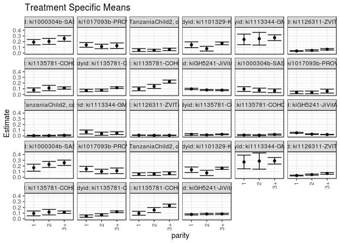

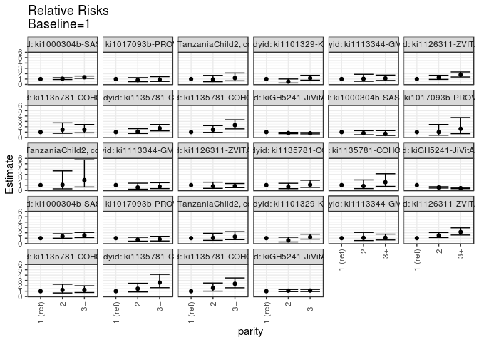

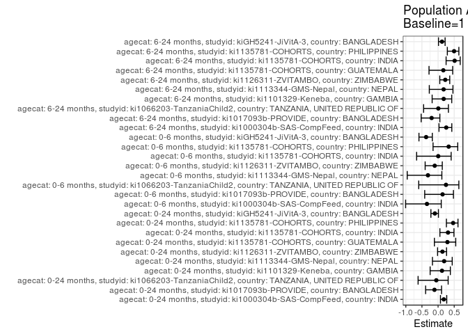

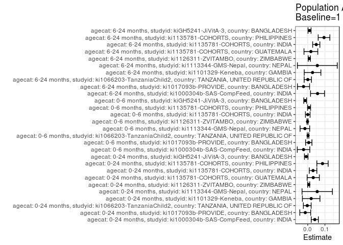

## Results Table

### Parameter: TSM

| agecat | studyid | country | intervention_level | baseline_level | estimate | ci_lower | ci_upper |
| --- | --- | --- | --- | --- | --- | --- | --- |
| 0-24 months | ki1000304b-SAS-CompFeed | INDIA | 1 | NA | 0.1909872 | 0.1440772 | 0.2378972 |
| 0-24 months | ki1000304b-SAS-CompFeed | INDIA | 2 | NA | 0.2045782 | 0.1526877 | 0.2564687 |
| 0-24 months | ki1000304b-SAS-CompFeed | INDIA | 3+ | NA | 0.2557599 | 0.2067739 | 0.3047459 |
| 0-24 months | ki1017093b-PROVIDE | BANGLADESH | 1 | NA | 0.1430133 | 0.1013869 | 0.1846397 |
| 0-24 months | ki1017093b-PROVIDE | BANGLADESH | 2 | NA | 0.1155070 | 0.0756058 | 0.1554081 |
| 0-24 months | ki1017093b-PROVIDE | BANGLADESH | 3+ | NA | 0.1291211 | 0.0806691 | 0.1775732 |
| 0-24 months | ki1066203-TanzaniaChild2 | TANZANIA, UNITED REPUBLIC OF | 1 | NA | 0.0528443 | 0.0284232 | 0.0772654 |
| 0-24 months | ki1066203-TanzaniaChild2 | TANZANIA, UNITED REPUBLIC OF | 2 | NA | 0.0489412 | 0.0300957 | 0.0677868 |
| 0-24 months | ki1066203-TanzaniaChild2 | TANZANIA, UNITED REPUBLIC OF | 3+ | NA | 0.0634689 | 0.0417532 | 0.0851847 |
| 0-24 months | ki1101329-Keneba | GAMBIA | 1 | NA | 0.1453816 | 0.0943549 | 0.1964084 |
| 0-24 months | ki1101329-Keneba | GAMBIA | 2 | NA | 0.0769214 | 0.0351382 | 0.1187045 |
| 0-24 months | ki1101329-Keneba | GAMBIA | 3+ | NA | 0.1695129 | 0.1447753 | 0.1942505 |
| 0-24 months | ki1113344-GMS-Nepal | NEPAL | 1 | NA | 0.2393001 | 0.1462176 | 0.3323826 |
| 0-24 months | ki1113344-GMS-Nepal | NEPAL | 2 | NA | 0.2514465 | 0.1399364 | 0.3629566 |
| 0-24 months | ki1113344-GMS-Nepal | NEPAL | 3+ | NA | 0.2698806 | 0.2189380 | 0.3208231 |
| 0-24 months | ki1126311-ZVITAMBO | ZIMBABWE | 1 | NA | 0.0366889 | 0.0301541 | 0.0432238 |
| 0-24 months | ki1126311-ZVITAMBO | ZIMBABWE | 2 | NA | 0.0463615 | 0.0351889 | 0.0575341 |
| 0-24 months | ki1126311-ZVITAMBO | ZIMBABWE | 3+ | NA | 0.0658612 | 0.0534242 | 0.0782981 |
| 0-24 months | ki1135781-COHORTS | GUATEMALA | 1 | NA | 0.0784059 | 0.0408413 | 0.1159704 |
| 0-24 months | ki1135781-COHORTS | GUATEMALA | 2 | NA | 0.1134564 | 0.0660405 | 0.1608723 |
| 0-24 months | ki1135781-COHORTS | GUATEMALA | 3+ | NA | 0.1137027 | 0.0934408 | 0.1339645 |
| 0-24 months | ki1135781-COHORTS | INDIA | 1 | NA | 0.0697941 | 0.0474406 | 0.0921475 |
| 0-24 months | ki1135781-COHORTS | INDIA | 2 | NA | 0.0764304 | 0.0574206 | 0.0954402 |
| 0-24 months | ki1135781-COHORTS | INDIA | 3+ | NA | 0.1199492 | 0.1056930 | 0.1342054 |
| 0-24 months | ki1135781-COHORTS | PHILIPPINES | 1 | NA | 0.0980806 | 0.0647407 | 0.1314206 |
| 0-24 months | ki1135781-COHORTS | PHILIPPINES | 2 | NA | 0.1416393 | 0.1056176 | 0.1776611 |
| 0-24 months | ki1135781-COHORTS | PHILIPPINES | 3+ | NA | 0.2255480 | 0.1983935 | 0.2527024 |
| 0-24 months | kiGH5241-JiVitA-3 | BANGLADESH | 1 | NA | 0.0976638 | 0.0863262 | 0.1090015 |
| 0-24 months | kiGH5241-JiVitA-3 | BANGLADESH | 2 | NA | 0.0797530 | 0.0712408 | 0.0882652 |
| 0-24 months | kiGH5241-JiVitA-3 | BANGLADESH | 3+ | NA | 0.0759714 | 0.0670691 | 0.0848737 |

[output cut: 54 more lines]

### Parameter: E(Y)

| agecat | studyid | country | intervention_level | baseline_level | estimate | ci_lower | ci_upper |
| --- | --- | --- | --- | --- | --- | --- | --- |
| 0-24 months | ki1000304b-SAS-CompFeed | INDIA | NA | NA | 0.2319894 | 0.1917264 | 0.2722524 |
| 0-24 months | ki1017093b-PROVIDE | BANGLADESH | NA | NA | 0.1285714 | 0.1037574 | 0.1533855 |
| 0-24 months | ki1066203-TanzaniaChild2 | TANZANIA, UNITED REPUBLIC OF | NA | NA | 0.0500636 | 0.0412578 | 0.0588694 |
| 0-24 months | ki1101329-Keneba | GAMBIA | NA | NA | 0.1654098 | 0.1490771 | 0.1817424 |
| 0-24 months | ki1113344-GMS-Nepal | NEPAL | NA | NA | 0.2944606 | 0.2603274 | 0.3285938 |
| 0-24 months | ki1126311-ZVITAMBO | ZIMBABWE | NA | NA | 0.0423929 | 0.0390482 | 0.0457376 |
| 0-24 months | ki1135781-COHORTS | GUATEMALA | NA | NA | 0.1103654 | 0.0935883 | 0.1271425 |
| 0-24 months | ki1135781-COHORTS | INDIA | NA | NA | 0.1008003 | 0.0921209 | 0.1094798 |
| 0-24 months | ki1135781-COHORTS | PHILIPPINES | NA | NA | 0.1839080 | 0.1701456 | 0.1976705 |
| 0-24 months | kiGH5241-JiVitA-3 | BANGLADESH | NA | NA | 0.0888460 | 0.0849398 | 0.0927521 |
| 0-6 months | ki1000304b-SAS-CompFeed | INDIA | NA | NA | 0.0704787 | 0.0478990 | 0.0930584 |
| 0-6 months | ki1017093b-PROVIDE | BANGLADESH | NA | NA | 0.0428571 | 0.0278427 | 0.0578716 |
| 0-6 months | ki1066203-TanzaniaChild2 | TANZANIA, UNITED REPUBLIC OF | NA | NA | 0.0080611 | 0.0044503 | 0.0116719 |
| 0-6 months | ki1113344-GMS-Nepal | NEPAL | NA | NA | 0.0524781 | 0.0357793 | 0.0691770 |
| 0-6 months | ki1126311-ZVITAMBO | ZIMBABWE | NA | NA | 0.0120621 | 0.0102437 | 0.0138805 |
| 0-6 months | ki1135781-COHORTS | INDIA | NA | NA | 0.0263336 | 0.0216247 | 0.0310424 |
| 0-6 months | ki1135781-COHORTS | PHILIPPINES | NA | NA | 0.0236531 | 0.0182537 | 0.0290525 |
| 0-6 months | kiGH5241-JiVitA-3 | BANGLADESH | NA | NA | 0.0396778 | 0.0371765 | 0.0421791 |
| 6-24 months | ki1000304b-SAS-CompFeed | INDIA | NA | NA | 0.2260619 | 0.1909133 | 0.2612105 |
| 6-24 months | ki1017093b-PROVIDE | BANGLADESH | NA | NA | 0.1221498 | 0.0962275 | 0.1480722 |
| 6-24 months | ki1066203-TanzaniaChild2 | TANZANIA, UNITED REPUBLIC OF | NA | NA | 0.0563948 | 0.0462467 | 0.0665428 |
| 6-24 months | ki1101329-Keneba | GAMBIA | NA | NA | 0.1612064 | 0.1447669 | 0.1776460 |
| 6-24 months | ki1113344-GMS-Nepal | NEPAL | NA | NA | 0.3254237 | 0.2875855 | 0.3632619 |
| 6-24 months | ki1126311-ZVITAMBO | ZIMBABWE | NA | NA | 0.0410655 | 0.0373248 | 0.0448061 |
| 6-24 months | ki1135781-COHORTS | GUATEMALA | NA | NA | 0.1123039 | 0.0945135 | 0.1300943 |
| 6-24 months | ki1135781-COHORTS | INDIA | NA | NA | 0.0965883 | 0.0877969 | 0.1053797 |
| 6-24 months | ki1135781-COHORTS | PHILIPPINES | NA | NA | 0.1908832 | 0.1763448 | 0.2054216 |
| 6-24 months | kiGH5241-JiVitA-3 | BANGLADESH | NA | NA | 0.0869213 | 0.0822621 | 0.0915805 |

### Parameter: RR

| agecat | studyid | country | intervention_level | baseline_level | estimate | ci_lower | ci_upper |
| --- | --- | --- | --- | --- | --- | --- | --- |
| 0-24 months | ki1000304b-SAS-CompFeed | INDIA | 1 | 1 | 1.0000000 | 1.0000000 | 1.0000000 |
| 0-24 months | ki1000304b-SAS-CompFeed | INDIA | 2 | 1 | 1.0711620 | 0.9159623 | 1.2526586 |
| 0-24 months | ki1000304b-SAS-CompFeed | INDIA | 3+ | 1 | 1.3391470 | 1.1386654 | 1.5749268 |
| 0-24 months | ki1017093b-PROVIDE | BANGLADESH | 1 | 1 | 1.0000000 | 1.0000000 | 1.0000000 |
| 0-24 months | ki1017093b-PROVIDE | BANGLADESH | 2 | 1 | 0.8076658 | 0.5152536 | 1.2660254 |
| 0-24 months | ki1017093b-PROVIDE | BANGLADESH | 3+ | 1 | 0.9028608 | 0.5617792 | 1.4510284 |
| 0-24 months | ki1066203-TanzaniaChild2 | TANZANIA, UNITED REPUBLIC OF | 1 | 1 | 1.0000000 | 1.0000000 | 1.0000000 |
| 0-24 months | ki1066203-TanzaniaChild2 | TANZANIA, UNITED REPUBLIC OF | 2 | 1 | 0.9261406 | 0.5075232 | 1.6900438 |
| 0-24 months | ki1066203-TanzaniaChild2 | TANZANIA, UNITED REPUBLIC OF | 3+ | 1 | 1.2010559 | 0.6756784 | 2.1349435 |
| 0-24 months | ki1101329-Keneba | GAMBIA | 1 | 1 | 1.0000000 | 1.0000000 | 1.0000000 |
| 0-24 months | ki1101329-Keneba | GAMBIA | 2 | 1 | 0.5290996 | 0.2770657 | 1.0103969 |
| 0-24 months | ki1101329-Keneba | GAMBIA | 3+ | 1 | 1.1659858 | 0.7982690 | 1.7030888 |
| 0-24 months | ki1113344-GMS-Nepal | NEPAL | 1 | 1 | 1.0000000 | 1.0000000 | 1.0000000 |
| 0-24 months | ki1113344-GMS-Nepal | NEPAL | 2 | 1 | 1.0507581 | 0.5827245 | 1.8947076 |
| 0-24 months | ki1113344-GMS-Nepal | NEPAL | 3+ | 1 | 1.1277914 | 0.7315598 | 1.7386323 |
| 0-24 months | ki1126311-ZVITAMBO | ZIMBABWE | 1 | 1 | 1.0000000 | 1.0000000 | 1.0000000 |
| 0-24 months | ki1126311-ZVITAMBO | ZIMBABWE | 2 | 1 | 1.2636376 | 0.9366406 | 1.7047950 |
| 0-24 months | ki1126311-ZVITAMBO | ZIMBABWE | 3+ | 1 | 1.7951240 | 1.3849309 | 2.3268095 |
| 0-24 months | ki1135781-COHORTS | GUATEMALA | 1 | 1 | 1.0000000 | 1.0000000 | 1.0000000 |
| 0-24 months | ki1135781-COHORTS | GUATEMALA | 2 | 1 | 1.4470398 | 0.7666566 | 2.7312415 |
| 0-24 months | ki1135781-COHORTS | GUATEMALA | 3+ | 1 | 1.4501809 | 0.8697803 | 2.4178802 |
| 0-24 months | ki1135781-COHORTS | INDIA | 1 | 1 | 1.0000000 | 1.0000000 | 1.0000000 |
| 0-24 months | ki1135781-COHORTS | INDIA | 2 | 1 | 1.0950841 | 0.7303947 | 1.6418645 |
| 0-24 months | ki1135781-COHORTS | INDIA | 3+ | 1 | 1.7186151 | 1.2217176 | 2.4176111 |
| 0-24 months | ki1135781-COHORTS | PHILIPPINES | 1 | 1 | 1.0000000 | 1.0000000 | 1.0000000 |
| 0-24 months | ki1135781-COHORTS | PHILIPPINES | 2 | 1 | 1.4441108 | 0.9450336 | 2.2067532 |
| 0-24 months | ki1135781-COHORTS | PHILIPPINES | 3+ | 1 | 2.2996174 | 1.6034975 | 3.2979410 |
| 0-24 months | kiGH5241-JiVitA-3 | BANGLADESH | 1 | 1 | 1.0000000 | 1.0000000 | 1.0000000 |
| 0-24 months | kiGH5241-JiVitA-3 | BANGLADESH | 2 | 1 | 0.8166075 | 0.7021412 | 0.9497347 |
| 0-24 months | kiGH5241-JiVitA-3 | BANGLADESH | 3+ | 1 | 0.7778868 | 0.6594891 | 0.9175404 |

[output cut: 54 more lines]

### Parameter: PAR

| agecat | studyid | country | intervention_level | baseline_level | estimate | ci_lower | ci_upper |
| --- | --- | --- | --- | --- | --- | --- | --- |
| 0-24 months | ki1000304b-SAS-CompFeed | INDIA | 1 | NA | 0.0410023 | 0.0202987 | 0.0617058 |
| 0-24 months | ki1017093b-PROVIDE | BANGLADESH | 1 | NA | -0.0144419 | -0.0459932 | 0.0171094 |
| 0-24 months | ki1066203-TanzaniaChild2 | TANZANIA, UNITED REPUBLIC OF | 1 | NA | -0.0027807 | -0.0253897 | 0.0198284 |
| 0-24 months | ki1101329-Keneba | GAMBIA | 1 | NA | 0.0200281 | -0.0309971 | 0.0710534 |
| 0-24 months | ki1113344-GMS-Nepal | NEPAL | 1 | NA | 0.0551606 | -0.0330685 | 0.1433896 |
| 0-24 months | ki1126311-ZVITAMBO | ZIMBABWE | 1 | NA | 0.0057040 | -0.0001867 | 0.0115948 |
| 0-24 months | ki1135781-COHORTS | GUATEMALA | 1 | NA | 0.0319595 | -0.0035277 | 0.0674468 |
| 0-24 months | ki1135781-COHORTS | INDIA | 1 | NA | 0.0310063 | 0.0091956 | 0.0528170 |
| 0-24 months | ki1135781-COHORTS | PHILIPPINES | 1 | NA | 0.0858274 | 0.0529628 | 0.1186920 |
| 0-24 months | kiGH5241-JiVitA-3 | BANGLADESH | 1 | NA | -0.0088179 | -0.0191717 | 0.0015360 |
| 0-6 months | ki1000304b-SAS-CompFeed | INDIA | 1 | NA | -0.0242966 | -0.0606613 | 0.0120681 |
| 0-6 months | ki1017093b-PROVIDE | BANGLADESH | 1 | NA | 0.0059568 | -0.0124634 | 0.0243770 |
| 0-6 months | ki1066203-TanzaniaChild2 | TANZANIA, UNITED REPUBLIC OF | 1 | NA | 0.0019710 | -0.0026802 | 0.0066221 |
| 0-6 months | ki1113344-GMS-Nepal | NEPAL | 1 | NA | -0.0164874 | -0.0443355 | 0.0113608 |
| 0-6 months | ki1126311-ZVITAMBO | ZIMBABWE | 1 | NA | -0.0012541 | -0.0044247 | 0.0019165 |
| 0-6 months | ki1135781-COHORTS | INDIA | 1 | NA | 0.0001175 | -0.0133631 | 0.0135980 |
| 0-6 months | ki1135781-COHORTS | PHILIPPINES | 1 | NA | 0.0077505 | -0.0010647 | 0.0165656 |
| 0-6 months | kiGH5241-JiVitA-3 | BANGLADESH | 1 | NA | -0.0146894 | -0.0228798 | -0.0064989 |
| 6-24 months | ki1000304b-SAS-CompFeed | INDIA | 1 | NA | 0.0570716 | 0.0162279 | 0.0979154 |
| 6-24 months | ki1017093b-PROVIDE | BANGLADESH | 1 | NA | -0.0244399 | -0.0597625 | 0.0108827 |
| 6-24 months | ki1066203-TanzaniaChild2 | TANZANIA, UNITED REPUBLIC OF | 1 | NA | 0.0004278 | -0.0207114 | 0.0215670 |
| 6-24 months | ki1101329-Keneba | GAMBIA | 1 | NA | 0.0279634 | -0.0204023 | 0.0763290 |
| 6-24 months | ki1113344-GMS-Nepal | NEPAL | 1 | NA | 0.0558542 | -0.0599261 | 0.1716346 |
| 6-24 months | ki1126311-ZVITAMBO | ZIMBABWE | 1 | NA | 0.0091245 | 0.0027731 | 0.0154758 |
| 6-24 months | ki1135781-COHORTS | GUATEMALA | 1 | NA | 0.0182982 | -0.0217676 | 0.0583640 |
| 6-24 months | ki1135781-COHORTS | INDIA | 1 | NA | 0.0495634 | 0.0286716 | 0.0704551 |
| 6-24 months | ki1135781-COHORTS | PHILIPPINES | 1 | NA | 0.0946790 | 0.0607101 | 0.1286479 |
| 6-24 months | kiGH5241-JiVitA-3 | BANGLADESH | 1 | NA | 0.0104979 | 0.0016210 | 0.0193748 |

### Parameter: PAF

| agecat | studyid | country | intervention_level | baseline_level | estimate | ci_lower | ci_upper |
| --- | --- | --- | --- | --- | --- | --- | --- |
| 0-24 months | ki1000304b-SAS-CompFeed | INDIA | 1 | NA | 0.1767419 | 0.0738453 | 0.2682067 |
| 0-24 months | ki1017093b-PROVIDE | BANGLADESH | 1 | NA | -0.1123258 | -0.3859948 | 0.1073065 |
| 0-24 months | ki1066203-TanzaniaChild2 | TANZANIA, UNITED REPUBLIC OF | 1 | NA | -0.0555423 | -0.6190157 | 0.3118229 |
| 0-24 months | ki1101329-Keneba | GAMBIA | 1 | NA | 0.1210819 | -0.2460688 | 0.3800526 |
| 0-24 months | ki1113344-GMS-Nepal | NEPAL | 1 | NA | 0.1873275 | -0.1746528 | 0.4377602 |
| 0-24 months | ki1126311-ZVITAMBO | ZIMBABWE | 1 | NA | 0.1345512 | -0.0156502 | 0.2625398 |
| 0-24 months | ki1135781-COHORTS | GUATEMALA | 1 | NA | 0.2895793 | -0.1142662 | 0.5470584 |
| 0-24 months | ki1135781-COHORTS | INDIA | 1 | NA | 0.3076008 | 0.0563058 | 0.4919787 |
| 0-24 months | ki1135781-COHORTS | PHILIPPINES | 1 | NA | 0.4666865 | 0.2581744 | 0.6165901 |
| 0-24 months | kiGH5241-JiVitA-3 | BANGLADESH | 1 | NA | -0.0992489 | -0.2219127 | 0.0111012 |
| 0-6 months | ki1000304b-SAS-CompFeed | INDIA | 1 | NA | -0.3447369 | -1.0051084 | 0.0981448 |
| 0-6 months | ki1017093b-PROVIDE | BANGLADESH | 1 | NA | 0.1389914 | -0.4142101 | 0.4757951 |
| 0-6 months | ki1066203-TanzaniaChild2 | TANZANIA, UNITED REPUBLIC OF | 1 | NA | 0.2445028 | -0.5993898 | 0.6431289 |
| 0-6 months | ki1113344-GMS-Nepal | NEPAL | 1 | NA | -0.3141762 | -0.9558762 | 0.1169895 |
| 0-6 months | ki1126311-ZVITAMBO | ZIMBABWE | 1 | NA | -0.1039716 | -0.4005479 | 0.1298024 |
| 0-6 months | ki1135781-COHORTS | INDIA | 1 | NA | 0.0044606 | -0.6648382 | 0.4046877 |
| 0-6 months | ki1135781-COHORTS | PHILIPPINES | 1 | NA | 0.3276732 | -0.1559545 | 0.6089610 |
| 0-6 months | kiGH5241-JiVitA-3 | BANGLADESH | 1 | NA | -0.3702162 | -0.5924334 | -0.1790085 |
| 6-24 months | ki1000304b-SAS-CompFeed | INDIA | 1 | NA | 0.2524602 | 0.0281482 | 0.4249991 |
| 6-24 months | ki1017093b-PROVIDE | BANGLADESH | 1 | NA | -0.2000811 | -0.5244123 | 0.0552459 |
| 6-24 months | ki1066203-TanzaniaChild2 | TANZANIA, UNITED REPUBLIC OF | 1 | NA | 0.0075856 | -0.4478540 | 0.3197613 |
| 6-24 months | ki1101329-Keneba | GAMBIA | 1 | NA | 0.1734630 | -0.1839990 | 0.4230034 |
| 6-24 months | ki1113344-GMS-Nepal | NEPAL | 1 | NA | 0.1716354 | -0.2720765 | 0.4605765 |
| 6-24 months | ki1126311-ZVITAMBO | ZIMBABWE | 1 | NA | 0.2221929 | 0.0527035 | 0.3613575 |
| 6-24 months | ki1135781-COHORTS | GUATEMALA | 1 | NA | 0.1629346 | -0.2808970 | 0.4529783 |
| 6-24 months | ki1135781-COHORTS | INDIA | 1 | NA | 0.5131405 | 0.2483621 | 0.6846458 |
| 6-24 months | ki1135781-COHORTS | PHILIPPINES | 1 | NA | 0.4960051 | 0.2871555 | 0.6436659 |
| 6-24 months | kiGH5241-JiVitA-3 | BANGLADESH | 1 | NA | 0.1207746 | 0.0127522 | 0.2169775 |